# Data Visualization - Ford GoBike System Data

by Laman Mammadli

27/07/2021

# Content

Data set Overview

Questions

Explanatory Analysis

Call to Action

### Data set Overview

This data set includes information about individual rides made in a bike-sharing system covering the greater San Francisco Bay area.

### Questions

- When are most trips taken in terms of time of day, day of the week?
- Does the average trip depend on if a user is a subscriber or customer?
- Does the average trip depend on if a user is a male or female?
- When the ride duration is the highest?
- Is there a relationship between the age of riders and the duration of the rides and distance?

### Explanatory Analysis

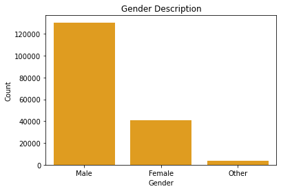

**Observation:**

**Male riders are more than female riders**

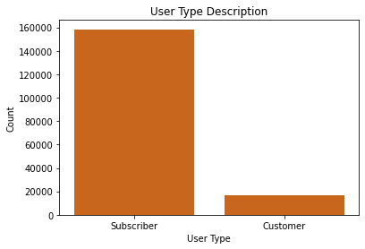

**Observation:**

**Subscriber riders are more than customer riders**

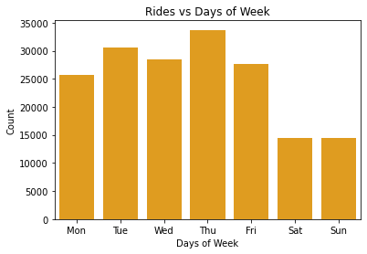

**Observation:**

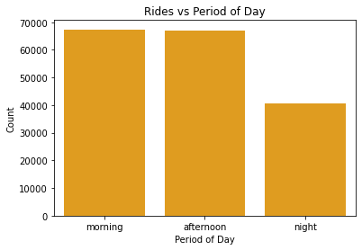

**Observation:**

**Riders are more active during the morning, and less active at nights.**

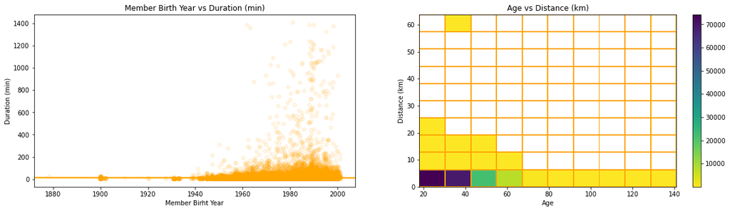

**Observation:**

**Young riders ride more in duration and in distance**

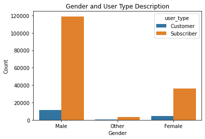

**Observation:**

**Male subscriber riders are more than female subscribers.**

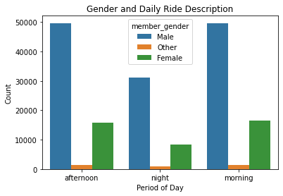

**Observation:**

**Male riders ride more during the day than female ones.**

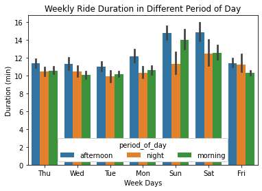

**Observation**

**During the weekends, afternoon ride duration average is the highest.**

### Call to Action

**Summary**

**Observation:** Rides are more during the morning than afternoon and night, rides are lower during the night

**Action:** Making the available number of the bikes during the morning is crucial

**Observation:** Younger people rides longer distance than older ones

**Observation:** Males are more prone to be subscriber than females Males ride more than females

**Action:** Target the female riders in marketing to increase the number of the female subscribers

**Observation:** During the weekends, duration of the rides are the highest on afternoons, however, in general, rides during the weekends are the lowest

**Action:** Making the available number of the bikes during the afternoon